Yuanfeng Li May-10-2021

# Part 1: Set-up

## 1. creating seed

```python
from numpy.random import seed
import tensorflow as tf
seed(1234)
tf.random.set_seed(seed=1234)
```

## 2. loading data

```python
# loading training and test datas
import pandas as pd

header = ["score", "text"]
train_df = pd.read_csv("train.tsv", sep='\t', names=header)
test_df = pd.read_csv("test.tsv", sep='\t', names=header)
```

```python
print(train_df.shape)
train_df.head()
```

```
(1515, 2)
```

|  | score | text |
| --- | --- | --- |
| 0 | 8.0 | dear caps1 caps2 people world use coumputers k... |
| 1 | 10.0 | dear newspaper believe advances technology man... |
| 2 | 6.0 | think caps1s use computers help selfs using co... |
| 3 | 9.0 | want child suceed life computers valuable ever... |
| 4 | 8.0 | dear local newspaper computers important peopl... |

```python
train_df.score.describe()
```

```
count    1515.000000
mean        8.518812
std         1.550177
min         2.000000
25%         8.000000
50%         8.000000
75%        10.000000
max        12.000000
Name: score, dtype: float64
```

```python
print(test_df.shape)
test_df.head()
```

```
(268, 2)
```

|  | score | text |
| --- | --- | --- |
| 0 | 11.0 | dear editor ever would know something badly ca... |
| 1 | 9.0 | computers everyone dont think heres caps1 gonn... |
| 2 | 11.0 | say computers bad todays society caps1 im prov... |
| 3 | 10.0 | dear editor ever stopped asked important cours... |
| 4 | 12.0 | study conducted organization1 num1 num2 people... |

```python
test_df.score.describe()
```

```
count    268.000000
mean       8.582090
std        1.472843
min        4.000000
25%        8.000000
50%        8.000000
75%       10.000000
max       12.000000
Name: score, dtype: float64
```

### Answer:

- There are 1515 rows of training data, with 2 columns
- There are 268 rows of test data, with 2 columns

## 3. Vector of training labels

```python
# tfidf vectors
from sklearn.feature_extraction.text import CountVectorizer

MAX_FEATURES = 1000
vectorizer = CountVectorizer(max_features=MAX_FEATURES)
tfidf_train = vectorizer.fit_transform(train_df.text.to_list())
tfidf_test = vectorizer.transform(test_df.text.to_list())
```

```python
vectorizer.get_feature_names()[:10]
```

```
['ability',
 'able',
 'access',
 'according',
 'account',
 'across',
 'act',
 'active',
 'activities',
 'activity']
```

```python
len(vectorizer.get_feature_names())
```

```
1000
```

```python
tfidf_train
```

```
<1515x1000 sparse matrix of type '<class 'numpy.int64'>'
	with 139566 stored elements in Compressed Sparse Row format>
```

```python
import numpy as np
from collections import Counter

print(len(tfidf_train.toarray()[0]))
# print(type(tfidf_train.toarray()))
# print("how many 0 in the vectors", np.count_nonzero(tfidf_train.toarray()[0] == 0))

# average 0 occurs
# c = Counter([(lambda x:np.count_nonzero(x == 0))(x) for x in tfidf_train.toarray()] )
total_list = [(lambda x:np.count_nonzero(x == 0))(x) for x in tfidf_train.toarray()]
print("Average 0 occurences in %s is %d times"\
      %(MAX_FEATURES, round(sum(total_list) / len(total_list),)))
# print(c)

tfidf_train.toarray()[:5]
# why mine is int, not float in demo?
```

```
1000
Average 0 occurences in 1000 is 908 times
```

```
array([[0, 0, 0, ..., 0, 0, 0],
       [0, 0, 0, ..., 0, 0, 1],
       [0, 0, 0, ..., 0, 0, 0],
       [0, 0, 0, ..., 0, 0, 0],
       [0, 1, 0, ..., 0, 0, 0]], dtype=int64)
```

```python
tfidf_test
```

```
<268x1000 sparse matrix of type '<class 'numpy.int64'>'
	with 25038 stored elements in Compressed Sparse Row format>
```

```python
print(len(tfidf_test.toarray()[0]))
tfidf_test.toarray()[:5]
```

```
1000
```

```
array([[0, 0, 0, ..., 1, 0, 0],
       [2, 1, 0, ..., 0, 0, 0],
       [2, 0, 0, ..., 2, 0, 1],
       [0, 0, 0, ..., 0, 0, 0],
       [0, 0, 0, ..., 0, 0, 0]], dtype=int64)
```

### Answer:

- The distribution of labels look very sparse, as you can see from the top 5 rows of tfidf_train and tfidf_text, it all has 1000 features for each text, and there are 908 times of 0 occurences in the trainning vectors, which make this vector very sparse.

## 4. Stop words

```python
# before we do anything let's take a look at the text
train_df.text.to_list()[0]
```

```
'dear caps1 caps2 people world use coumputers know computers used like surching internet games work school people think computers good use help teach hand eye coordination learn places world talk people online num1 grade mystic middle school think computers good people think ever heard computer camp…
```

```python
# we can see that all the training data has already converted to lower case, and punctuation
# already removed from the training data.
# we would still want to write the preprocessing function, even though Sean has done the job
from nltk.corpus import stopwords
stops_ori = stopwords.words('english')
```

```python
# preprocessing text
import regex as re

def preproc(target_text_list, target_stops):
    '''
    type: target_text - list of string
    rtype: list of string - lower case, no puctuation and no stop words in english
    '''
    texts = []

    for text in target_text_list:
        text = re.sub(r"@[\w]+", '', text)
        text = re.sub(r"[^\w\s]", '', text)
        text = text.lower().strip()
        text = text.split()

        text = ' '.join([x for x in words if x not in target_stops])
        texts.append(text)

    return texts
```

```python
## in addition to the traditional stop words
# I find there are a lot of words wich starting with caps
# such as 'caps1', 'caps2', 'caps3' and so on.
# so I will try to remove all of them as well.

# preprocessing text version 02
import regex as re

def preproc(target_text_list, target_stops):
    '''
    type: target_text - list of string
    rtype: list of string - lower case, no puctuation and no stop words in english
    '''
    texts = []

    for text in target_text_list:
        text = re.sub(r"@[\w]+", '', text)
        text = re.sub(r"[^\w\s]", '', text)
        text = re.sub(r"\b\w+\d+\b", '', text)
        text = text.lower().strip()
        text = text.split()

        text = ' '.join([x for x in text if x not in target_stops])
        texts.append(text)

    return texts
```

```python
# now let's convert the training datasets

score_list_noStop = train_df.score.to_list()
text_list_noStop = preproc(train_df.text.to_list(), stops_ori)

data_noStop = {'score':score_list_noStop, 'text':text_list_noStop}

proced_train_text = pd.DataFrame(data_noStop)
```

```python
proced_train_text.head()
```

|  | score | text |
| --- | --- | --- |
| 0 | 8.0 | dear people world use coumputers know computer... |
| 1 | 10.0 | dear newspaper believe advances technology man... |
| 2 | 6.0 | think caps1s use computers help selfs using co... |
| 3 | 9.0 | want child suceed life computers valuable ever... |
| 4 | 8.0 | dear local newspaper computers important peopl... |

```python
proced_train_text.text.to_list()[1]
# fun fact, there are lots of typos, such as familys,
# can we use stem to correct it?
```

```
'dear newspaper believe advances technology many positive effects computers computers great people ages computers teach handeye coordination allow people learn information world lastly computers allow people communicate internet advances technology improve society way life around globe advances tech…
```

### Answer:

These words are placeholders, such as caps1, caps2, organization1, num1 and so on. These words do not have that much meaning, and they all starting from the same prefix with a integer as its suffix. Which should not usesd as predictors in the vectors.

## 5. Stemming and Lemmatize

```python
# stemming it !
from nltk.stem import PorterStemmer

def stem(target_text_list):
    ps = PorterStemmer()
    words = []

    for text in target_text_list:
        text = text.split()

        text = ' '.join([(lambda x: ps.stem(x))(x) for x in text])
        words.append(text)

    return words
# test
t_proced_train_text = stem(proced_train_text.text.to_list())
```

```python
# test
print(t_proced_train_text[0], '\n')
print(proced_train_text.text.to_list()[0])
```

```
dear peopl world use coumput know comput use like surch internet game work school peopl think comput good use help teach hand eye coordin learn place world talk peopl onlin grade mystic middl school think comput good peopl think ever heard comput camp kid go addict comput camp kid pull away comput p…

dear people world use coumputers know computers used like surching internet games work school people think computers good use help teach hand eye coordination learn places world talk people online grade mystic middle school think computers good people think ever heard computer camps kids go addicted…
```

```python
# now we can lemmatize the whole proc_train_text
stem_s = proced_train_text.score.to_list()
stem_t = t_proced_train_text
data_stem = {'score':stem_s, 'text':stem_t}
stem_train_text = pd.DataFrame(data_stem)
```

```python
stem_train_text.head()
```

|  | score | text |
| --- | --- | --- |
| 0 | 8.0 | dear peopl world use coumput know comput use l... |
| 1 | 10.0 | dear newspap believ advanc technolog mani posi... |
| 2 | 6.0 | think caps1 use comput help self use comput fi... |
| 3 | 9.0 | want child suce life comput valuabl everyday l... |
| 4 | 8.0 | dear local newspap comput import peopl everyon... |

```python
# now let's using lemmatizaiton
from nltk.stem import WordNetLemmatizer

def lemma(target_text_list):
    wordnet_lemmatizer = WordNetLemmatizer()
    words = []

    for text in target_text_list:
        text = text.split()
        text = ' '.join([(lambda x: wordnet_lemmatizer.lemmatize(x))(x) for x in text])
        words.append(text)

    return words

lemma_train_text = lemma(proced_train_text.text.to_list())
```

```python
print(lemma_train_text[0], '\n\n', proced_train_text.text.to_list()[0])
```

```
dear people world use coumputers know computer used like surching internet game work school people think computer good use help teach hand eye coordination learn place world talk people online grade mystic middle school think computer good people think ever heard computer camp kid go addicted comput…

 dear people world use coumputers know computers used like surching internet games work school people think computers good use help teach hand eye coordination learn places world talk people online grade mystic middle school think computers good people think ever heard computer camps kids go addicte…
```

## 6. tokenize - unigrams

```python
# lets use the lemmatized data frame first
lemma_text = lemma_train_text
lemma_score = score_list_noStop
lemma_data = {'score':lemma_score, 'text':lemma_text}
lemma_df = pd.DataFrame(lemma_data)
```

```python
lemma_df.head()
```

|  | score | text |
| --- | --- | --- |
| 0 | 8.0 | dear people world use coumputers know computer... |
| 1 | 10.0 | dear newspaper believe advance technology many... |
| 2 | 6.0 | think caps1s use computer help self using comp... |
| 3 | 9.0 | want child suceed life computer valuable every... |
| 4 | 8.0 | dear local newspaper computer important people... |

```python
# even though we had done it earlier, but since we have lemmatized the texts,
# lets do the unigram first, and we could change this parameters in future
from sklearn.feature_extraction.text import CountVectorizer
NGRAM_RANGE = (1,1) # 13308 vocabulary
# NGRAM_RANGE = (1,2)  # 138996 vocabularies count

corpus_lemma = lemma_df.text.to_list()
vectorizer_lemma = CountVectorizer(ngram_range=NGRAM_RANGE)
lemma_tokenize = vectorizer_lemma.fit_transform(corpus_lemma)
```

```python
lemma_tokenize.toarray()
```

```
array([[0, 0, 0, ..., 0, 0, 0],
       [0, 0, 0, ..., 0, 0, 0],
       [0, 0, 0, ..., 0, 0, 0],
       ...,
       [0, 0, 0, ..., 0, 0, 0],
       [0, 0, 0, ..., 0, 0, 0],
       [0, 0, 0, ..., 0, 0, 0]], dtype=int64)
```

```python
# put them in pivkle file in order to use in future
import pickle
pickle.dump(vectorizer_lemma, open("vectorizer_lemma.pickle", "wb"))
# pickle.load(open("models/vectorizer.pickle", 'rb'))
```

```python
len(vectorizer_lemma.get_feature_names())
```

```
13308
```

```python
vectorizer_lemma.get_feature_names()[:20]
```

```
['aa',
 'aamous',
 'aare',
 'abad',
 'abandoned',
 'abat',
 'abd',
 'abduction',
 'abe',
 'abease',
 'abeast',
 'abel',
 'abenefit',
 'abese',
 'abesity',
 'abetter',
 'abide',
 'abiity',
 'abile',
 'abilit']
```

```python
vectorizer.get_feature_names()[:20]
```

```
['ability',
 'able',
 'access',
 'according',
 'account',
 'across',
 'act',
 'active',
 'activities',
 'activity',
 'actually',
 'add',
 'addicted',
 'addicting',
 'addiction',
 'addition',
 'adult',
 'adults',
 'advance',
 'advanced']
```

### Answer:

- I have tried to use only unigrams, and (unigrams + bigrams), and for unigram there are 13308 vocabulary. For (unigrams + bigrams) there are 138996 vocabularies.
- since 138996 is pretty large, and it might make the vector way much too sparse, so I choose to use unigram only as the result.

## 7(a) test_data

```python
# first let's also lemmatize the train data
test_lemma = lemma(test_df.text.to_list())
test_lemma = preproc(test_lemma, stops_ori)

lemma_text_test = test_lemma
lemma_score_test = test_df.score.to_list()
lemma_data_test = {'score':lemma_score_test, 'text':lemma_text_test}
lemma_test_df = pd.DataFrame(lemma_data_test)
```

```python
lemma_test_df.head()
```

|  | score | text |
| --- | --- | --- |
| 0 | 11.0 | dear editor ever would know something badly ca... |
| 1 | 9.0 | computer everyone dont think gonna convince co... |
| 2 | 11.0 | say computer bad today society im prove wrong ... |
| 3 | 10.0 | dear editor ever stopped asked important cours... |
| 4 | 12.0 | study conducted people spending hour day compu... |

```python
from sklearn.feature_extraction.text import CountVectorizer

tfidf_train_lemma = lemma_tokenize
tfidf_test_lemma = vectorizer_lemma.transform(test_df.text.to_list())
```

```python
print(tfidf_train_lemma.shape)
print(tfidf_test_lemma.shape)
# I have modified the trainning input variables twith the same dimensions.
# As you can see all of them have 13308 features.
```

```
(1515, 13308)
(268, 13308)
```

```python
# However, in oder to provide better predictions we may minimize the features,
# lets use 300, 500, 1000 as examples.
from sklearn.feature_extraction.text import CountVectorizer
MAX_FEATURES = 1000

def create_text_inputs(target_max_features=None):
    """
    rtype: tfidf_train_lem_no, tfidf_test_lem_no
    """
    vectorizer = CountVectorizer(max_features=target_max_features)
    tfidf_train = vectorizer.fit_transform(lemma_df.text.to_list())
    tfidf_test = vectorizer.transform(lemma_test_df.text.to_list())

    return tfidf_train, tfidf_test   # this should be token instead of tfidf.

# test using
# a, b = create_text_inputs(1000)
a, b = create_text_inputs()
print(a.shape, '\n\n', b.shape)
```

```
(1515, 13308)

 (268, 13308)
```

# Part 2: Supervised Learning

## 7(b).

```python
# using TF-IDF model
from sklearn.feature_extraction.text import TfidfVectorizer
MAX_FEATURES = 1000

def create_text_inputs_tfidf(target_max_features=None):
    """
    rtype: tfidf_train_lem_no, tfidf_test_lem_no
    """
    vectorizer = TfidfVectorizer(stop_words = 'english',
                                 max_features=target_max_features,
                                max_df=0.5,
                                smooth_idf = True)
    tfidf_train = vectorizer.fit_transform(lemma_df.text.to_list())
    tfidf_test = vectorizer.transform(lemma_test_df.text.to_list())

    return tfidf_train, tfidf_test
```

```python
tfidf_train_fv, tfidf_test_fv = create_text_inputs_tfidf(1000)
```

### Answer:

- I will only use tf-idf here, because my class projects will focusing on the same issue,
- So I will try using sentiments, bi-grams, topic-modelings and others as inputs in the final project

## 8. Two models

```python
# we will only using the tfidfs, and now lets see
from sklearn.preprocessing import MaxAbsScaler
tfidf_scaler = MaxAbsScaler()

tfidf_x_train = tfidf_scaler.fit_transform(tfidf_train_fv)
tfidf_x_test = tfidf_scaler.transform(tfidf_test_fv)
```

```python
# we need to understand y
y_train = lemma_df.score.to_list()
y_test = lemma_test_df.score.to_list()

print(type(tfidf_x_train), tfidf_x_train.shape,len(y_train))
print(type(tfidf_x_test), tfidf_x_test.shape,len(y_test))
```

```
<class 'scipy.sparse.csr.csr_matrix'> (1515, 1000) 1515
<class 'scipy.sparse.csr.csr_matrix'> (268, 1000) 268
```

```python
from sklearn.metrics import mean_squared_error
from sklearn.linear_model import Ridge
tfidf_linReg = Ridge()
tfidf_linReg.fit(tfidf_x_train, y_train)
linear = mean_squared_error(y_test, tfidf_linReg.predict(tfidf_x_test))
linear
```

```
1.498738639424935
```

### Answer for first model:

- The coeffiecient is 1.4987 for mean squared error. I have no idea how good it is performing, so I am going to use the second model in the following and see which one is performing better.

```python
# sentBert
from sentence_transformers import SentenceTransformer
sentBert = SentenceTransformer('paraphrase-distilroberta-base-v1')
```

```python
from tqdm.auto import tqdm

sentBert_x_train = []
sentBert_x_test = []

x_train = lemma_df.text.to_list()
x_test = lemma_test_df.text.to_list()

for i in tqdm(range(len(x_train))):
    emb = sentBert.encode(x_train[i])
    sentBert_x_train.append(emb)
sentBert_x_train = np.asarray(sentBert_x_train)

for i in tqdm(range(len(x_test))):
    emb = sentBert.encode(x_test[i])
    sentBert_x_test.append(emb)
sentBert_x_test = np.asarray(sentBert_x_test)
```

```python
# sentBert_x_train[0]
```

```python
# sentBert_x_test[0]
```

```python
sentBert_scaler = MaxAbsScaler()
sentBert_x_train = sentBert_scaler.fit_transform(sentBert_x_train)
sentBert_x_test = sentBert_scaler.transform(sentBert_x_test)
```

```python
sentBert_linReg = Ridge()
sentBert_linReg.fit(sentBert_x_train, y_train)
bert = mean_squared_error(y_test, sentBert_linReg.predict(sentBert_x_test))
bert
```

```
1.8330355055461793
```

### Answer for 2nd model

- it turns out that bert model has a larger MSE than the tf-idf method.
- which shows me that the tf-idf might perform better than bert here.

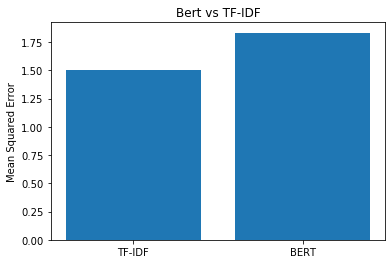

```python
import matplotlib.pyplot as plt

names = ["TF-IDF", "BERT"]
MSE = [linear, bert]
plt.bar(names, MSE)
plt.ylabel("Mean Squared Error")
plt.title("Bert vs TF-IDF")
plt.show()
```

## 9. more models

- 1. SVM

```python
from sklearn.svm import SVC

# lets try to use polynomial
svm_poly = SVC(kernel='poly')
svm_poly.fit(tfidf_x_train, y_train)
svm_poly_r = mean_squared_error(y_test, svm_poly.predict(tfidf_x_test))
svm_poly_r
```

```
2.5
```

```python
# lets try to use SVM
from sklearn.svm import SVC

svm_linear = SVC(kernel = 'linear')
svm_linear.fit(tfidf_x_train, y_train)

svm_linear_r = mean_squared_error(y_test, svm_linear.predict(tfidf_x_test))
svm_linear_r
```

```
2.1641791044776117
```

```python
svm_poly = SVC(kernel='rbf')
svm_poly.fit(tfidf_x_train, y_train)
svm_rbf_r = mean_squared_error(y_test, svm_poly.predict(tfidf_x_test))
svm_rbf_r
```

```
2.041044776119403
```

```python
svm_poly = SVC(kernel='sigmoid')
svm_poly.fit(tfidf_x_train, y_train)
svm_sigmoid_r = mean_squared_error(y_test, svm_poly.predict(tfidf_x_test))
svm_sigmoid_r
```

```
1.8097014925373134
```

- 1. Naive Bayes

```python
from sklearn.naive_bayes import GaussianNB

gnb = GaussianNB()
gnb.fit(tfidf_x_train.toarray(), y_train)
gnb_r = mean_squared_error(y_test, gnb.predict(tfidf_x_test.toarray()))
gnb_r
```

```
4.17910447761194
```

```python
from sklearn.naive_bayes import ComplementNB

gnb = ComplementNB()
gnb.fit(tfidf_x_train.toarray(), y_train)
gnb_cnb = mean_squared_error(y_test, gnb.predict(tfidf_x_test.toarray()))
gnb_cnb
```

```
2.291044776119403
```

```python
from sklearn.naive_bayes import MultinomialNB

gnb = MultinomialNB()
gnb.fit(tfidf_x_train.toarray(), y_train)
gnb_mtb = mean_squared_error(y_test, gnb.predict(tfidf_x_test.toarray()))
gnb_mtb
```

```
1.8320895522388059
```

```python
from sklearn.naive_bayes import BernoulliNB

gnb = BernoulliNB()
gnb.fit(tfidf_x_train.toarray(), y_train)
gnb_bnb = mean_squared_error(y_test, gnb.predict(tfidf_x_test.toarray()))
gnb_bnb
```

```
1.2276119402985075
```

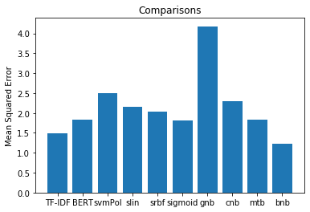

```python
import matplotlib.pyplot as plt

names = ["TF-IDF", "BERT", "svmPol", "slin", "srbf", "sigmoid", \
        "gnb", "cnb", "mtb", "bnb"]
MSE = [linear, bert, svm_poly_r, svm_linear_r, svm_rbf_r, svm_sigmoid_r,\
      gnb_r, gnb_cnb, gnb_mtb, gnb_bnb]

plt.bar(names, MSE)
plt.ylabel("Mean Squared Error")
plt.title("Comparisons")
plt.show()
```

```python
tfidf_x_train.shape[0]
# len(y_train)
```

```
1515
```

## 10. Compare

### Answer:

- Comparing SVM, Linear Regression, Naive Bayes, the strongest is BernoulliNB (MSE=1.2), the weakest is GaussianNB (MSE = 4.17)

# Part3: Deep Sentence Embedder

### 13 - 16

```python
# Universal Sentence Encoder
import tensorflow_hub as hub
module_url = "https://tfhub.dev/google/universal-sentence-encoder/4"
use = hub.load(module_url)
print("module %s loaded" % module_url)
```

```
INFO:absl:Using C:\Users\Jacky\AppData\Local\Temp\tfhub_modules to cache modules.
```

```
module https://tfhub.dev/google/universal-sentence-encoder/4 loaded
```

```python
use_x_train = []
use_x_test = []

use_x_train = use(x_train)
use_x_test = use(x_test)
```

```python
use_linReg = Ridge()
use_linReg.fit(use_x_train, y_train)
mean_squared_error(y_test, use_linReg.predict(use_x_test))
```

```
0.8706400996563491
```

```python
# feed into BernoulliNB
from sklearn.naive_bayes import BernoulliNB

bnb = BernoulliNB()
bnb.fit(use_x_train, y_train)
bnb_emb = mean_squared_error(y_test, bnb.predict(use_x_test))
bnb_emb
```

```
1.705223880597015
```

```python
# lets try to use SVM with linear kernel
from sklearn.svm import SVC

svm_linear_use = SVC(kernel = 'linear')
svm_linear_use.fit(use_x_train, y_train)

svm_linear_r_use = mean_squared_error(y_test, svm_linear_use.predict(use_x_test))
svm_linear_r_use
```

```
1.4962686567164178
```

### Answer:

I have feed my embeddings into the linear regression as one example, and it perform way much better! SVM's linear kernel perfomed better when we feed in embeddings, and better than TF-IDF! However, the BernoulliNB has not outperformed its TF-IDF features.

# References/usefulURLs

```python
# https://www.guru99.com/stemming-lemmatization-python-nltk.html
```